# Prerequisite

#### please run the below code to install the required packages

```python
!pip install -r requirements.txt
```

#### import all pakcages to be used

```python
import pandas as pd
from pandas.tseries.offsets import MonthEnd
from pandas.api.types import is_string_dtype
from pandas.api.types import is_numeric_dtype,is_float_dtype
from sklearn.pipeline import make_pipeline, make_union,Pipeline,FeatureUnion
from sklearn.compose import ColumnTransformer
from sklearn.impute import SimpleImputer
from sklearn.base import BaseEstimator, TransformerMixin
from sklearn.model_selection import train_test_split
from sklearn.preprocessing import FunctionTransformer,OneHotEncoder
from sklearn import ensemble
from sklearn.ensemble import RandomForestClassifier
from sklearn import metrics
from sklearn.metrics import roc_curve, auc
from bayes_opt import BayesianOptimization
from skopt import BayesSearchCV
from sklearn.model_selection import StratifiedKFold, KFold
from xgboost.sklearn import XGBClassifier
import xgboost as xgb
import shap
import pickle
from imblearn.pipeline import Pipeline
from imblearn.over_sampling import SMOTE
from imblearn.under_sampling import RandomUnderSampler
from IPython.display import display, Image
from utils import *

import numpy as np
from scipy.stats import ttest_ind
import scipy.stats as statss
import statsmodels.api as sm

import statsmodels
from zipfile import ZipFile
import os
import re
import json
from tqdm import tqdm
import warnings
warnings.filterwarnings('ignore')
import matplotlib.pyplot as plt
import seaborn as sns
from matplotlib import rcParams

%config InlineBackend.figure_format = 'retina'
%reload_ext autoreload
%autoreload 2
rcParams.update({'figure.autolayout': True})
pd.set_option('display.max_columns', 1000)
pd.set_option('display.width', 1000)
```

```
WARNING:tensorflow:From /home/ec2-user/anaconda3/envs/tensorflow_p36/lib/python3.6/site-packages/tensorflow_core/__init__.py:1473: The name tf.estimator.inputs is deprecated. Please use tf.compat.v1.estimator.inputs instead.
```

# Question 1: Load

### 1.1 Programmatically download and load into your favorite analytical tool the transactions data.

#### clone the git repo and unzip the data to folder "data/"

```python
#git clone the remote repository into local
!git clone https://github.com/CapitalOneRecruiting/DS.git
```

```
Cloning into 'DS'...
remote: Enumerating objects: 4, done.
remote: Total 4 (delta 0), reused 0 (delta 0), pack-reused 4
Unpacking objects: 100% (4/4), done.
```

```python
#list content in the cloned folder
os.listdir("DS/")
```

```
['.git', 'README.md', 'transactions.zip']
```

```python
#unzip the "transactions.zip" file to the data folder.

# make data folder if not exist
data_dir = "data/"
if not os.path.exists(data_dir):
    os.makedirs(data_dir)
# specifying file path and unzip it
file_name = "DS/transactions.zip"

with ZipFile(file_name, 'r') as z:
    # extracting the files
    print('Extracting now...')
    z.extractall(path=data_dir)
    print('Extracted to folder {}'.format(data_dir))
```

```
Extracting now...
Extracted to folder data/
```

```python
#list content in the data folder
os.listdir(data_dir)
```

```
['transactions.txt']
```

#### load the data into pandas dataframe and optimize the data size

```python
#data_dir = "data/"
# #card = pd.read_json(os.path.join(data_dir,"transactions.txt"),lines=True)
data = [json.loads(line) for line in open(os.path.join(data_dir,"transactions.txt"),'r')]
card = pd.DataFrame(data)
```

we could see from info() of the dataset that all the numeric columns are occupying 8 bytes of the memory but actually their values are not that big; Besides, some object dataype can be converted into category [2]

```python
card.info()
```

[output not shown]

[output cut: 21 more lines]

```python
start_mem_usg = card.memory_usage().sum() / 1024**2
print("Memory usage of properties dataframe is :",start_mem_usg," MB")
```

```
Memory usage of properties dataframe is : 158.23623752593994  MB
```

```python
for c in card.columns.tolist():
    if is_numeric_dtype(card[c]):
        if is_float_dtype(card[c]):
            card[c]=pd.to_numeric(card[c], downcast="float")
        else:
            card[c]=pd.to_numeric(card[c], downcast="integer")
```

```python
object2cat_cols = ["merchantName","acqCountry","merchantCountryCode","posEntryMode",\
                   "posConditionCode","merchantCategoryCode","cardCVV","enteredCVV",\
                   "transactionType","cardLast4Digits"]
```

```python
card[object2cat_cols] = card[object2cat_cols].astype('category')
```

```python
print("___MEMORY USAGE AFTER COMPLETION:___")
mem_usg = card.memory_usage().sum() / 1024**2
print("Memory usage is: ",mem_usg," MB")
print("This is ",100*mem_usg/start_mem_usg,"% of the initial size")
```

```
___MEMORY USAGE AFTER COMPLETION:___
Memory usage is:  97.12916088104248  MB
This is  61.382375111844986 % of the initial size
```

#### save into feather format as it lives in RAM

```python
# save to feather format for future use
# Feather format is almost the same format that it lives in RAM, so it is ridiculously fast to read and write
card.to_feather('data/transactions-raw')
```

```python
# read the feather data back
card = pd.read_feather('data/transactions-raw')
```

### 1.2 Please describe the structure of the data. Number of records and fields in each record?

#### Answers - describe the structure

```python
# display 5 transactions from the bottom of the dataset and Transpose them for better view
display_all(card.tail(5).T)
```

|  | 786358 | 786359 | 786360 | 786361 | 786362 |
| --- | --- | --- | --- | --- | --- |
| accountNumber | 732852505 | 732852505 | 732852505 | 732852505 | 732852505 |
| customerId | 732852505 | 732852505 | 732852505 | 732852505 | 732852505 |
| creditLimit | 50000.0 | 50000.0 | 50000.0 | 50000.0 | 50000.0 |
| availableMoney | 48904.960938 | 48785.039062 | 48766.148438 | 48716.71875 | 48666.828125 |
| transactionDateTime | 2016-12-22T18:44:12 | 2016-12-25T16:20:34 | 2016-12-27T15:46:24 | 2016-12-29T00:30:55 | 2016-12-30T20:10:29 |
| transactionAmount | 119.919998 | 18.889999 | 49.43 | 49.889999 | 72.18 |
| merchantName | Lyft | hulu.com | Lyft | walmart.com | Uber |
| acqCountry | US | US | US | US | US |
| merchantCountryCode | US | US | US | US | US |
| posEntryMode | 90 | 09 | 02 | 09 | 05 |
| posConditionCode | 01 | 01 | 01 | 99 | 01 |
| merchantCategoryCode | rideshare | online_subscriptions | rideshare | online_retail | rideshare |
| currentExpDate | 12/2022 | 08/2023 | 08/2025 | 07/2022 | 05/2024 |
| accountOpenDate | 2012-08-23 | 2012-08-23 | 2012-08-23 | 2012-08-23 | 2012-08-23 |
| dateOfLastAddressChange | 2012-08-23 | 2012-08-23 | 2012-08-23 | 2012-08-23 | 2012-08-23 |
| cardCVV | 936 | 939 | 936 | 939 | 939 |
| enteredCVV | 936 | 939 | 936 | 939 | 939 |
| cardLast4Digits | 3783 | 3388 | 3783 | 3388 | 3388 |
| transactionType | PURCHASE | PURCHASE | PURCHASE | PURCHASE | PURCHASE |
| echoBuffer |  |  |  |  |  |
| currentBalance | 1095.040039 | 1214.959961 | 1233.849976 | 1283.280029 | 1333.170044 |
| merchantCity |  |  |  |  |  |
| merchantState |  |  |  |  |  |
| merchantZip |  |  |  |  |  |
| cardPresent | False | False | False | False | False |
| posOnPremises |  |  |  |  |  |
| recurringAuthInd |  |  |  |  |  |
| expirationDateKeyInMatch | False | False | False | False | False |
| isFraud | False | False | False | False | False |

```python
# check the shape of original data
print("{} rows and {} columns".format(card.shape[0],card.shape[1]))
```

```
786363 rows and 29 columns
```

```python
card.info()
```

```
<class 'pandas.core.frame.DataFrame'>
RangeIndex: 786363 entries, 0 to 786362
Data columns (total 29 columns):
 #   Column                    Non-Null Count   Dtype
---  ------                    --------------   -----
 0   accountNumber             786363 non-null  object
 1   customerId                786363 non-null  object
 2   creditLimit               786363 non-null  float32
 3   availableMoney            786363 non-null  float32
 4   transactionDateTime       786363 non-null  datetime64[ns]
 5   transactionAmount         786363 non-null  float32
 6   merchantName              786363 non-null  category
 7   acqCountry                781801 non-null  category
 8   merchantCountryCode       785639 non-null  category
 9   posEntryMode              782309 non-null  category
```

[output cut: 21 more lines]

### 1.3 Please provide some additional basic summary statistics for each field.

I would do an initial clean on the data first and then print the stats.

- convert date columns to datetime datatype
- deal with missing value and remove columns with all missing values
- remove duplicated columns

#### clean the data - datetime columns

##### for the expiration date, complete the 'day' part with the last day of that month

```python
# print all columns
card.columns
```

```
Index(['accountNumber', 'customerId', 'creditLimit', 'availableMoney', 'transactionDateTime', 'transactionAmount', 'merchantName', 'acqCountry', 'merchantCountryCode', 'posEntryMode', 'posConditionCode', 'merchantCategoryCode', 'currentExpDate', 'accountOpenDate', 'dateOfLastAddressChange', 'cardCVV…
       'transactionType', 'echoBuffer', 'currentBalance', 'merchantCity', 'merchantState', 'merchantZip', 'cardPresent', 'posOnPremises', 'recurringAuthInd', 'expirationDateKeyInMatch', 'isFraud'],
      dtype='object')
```

```python
# convert time-related columns to datetime format
for c in ["transactionDateTime","accountOpenDate","dateOfLastAddressChange"]:
    card[c]=pd.to_datetime(card[c])

# convert and complete (add the last day of month) the currentExpDate column [1]
card['currentExpDate'] = pd.to_datetime(card['currentExpDate']) + MonthEnd(1)
```

```python
# check
card[["transactionDateTime","accountOpenDate","dateOfLastAddressChange",'currentExpDate']].head()
```

|  | transactionDateTime | accountOpenDate | dateOfLastAddressChange | currentExpDate |
| --- | --- | --- | --- | --- |
| 0 | 2016-08-13 14:27:32 | 2015-03-14 | 2015-03-14 | 2023-06-30 |
| 1 | 2016-10-11 05:05:54 | 2015-03-14 | 2015-03-14 | 2024-02-29 |
| 2 | 2016-11-08 09:18:39 | 2015-03-14 | 2015-03-14 | 2025-08-31 |
| 3 | 2016-12-10 02:14:50 | 2015-03-14 | 2015-03-14 | 2025-08-31 |
| 4 | 2016-03-24 21:04:46 | 2015-08-06 | 2015-08-06 | 2029-10-31 |

#### clean the data - missing values

##### after examing the data, the null values in the json text data are represented by "", So i will replace them with np.nan

```python
for c in tqdm(card.columns):
    card[c] = card[c].map(lambda x: np.nan if x =='' else x)
```

```python
# check null values of each fields
card.isnull().sum()
```

```
accountNumber                    0
customerId                       0
creditLimit                      0
availableMoney                   0
transactionDateTime              0
transactionAmount                0
merchantName                     0
acqCountry                    4562
merchantCountryCode            724
posEntryMode                  4054
posConditionCode               409
merchantCategoryCode             0
currentExpDate                   0
accountOpenDate                  0
dateOfLastAddressChange          0
cardCVV                          0
enteredCVV                       0
cardLast4Digits                  0
transactionType                698
echoBuffer                  786363
currentBalance                   0
merchantCity                786363
merchantState               786363
merchantZip                 786363
cardPresent                      0
posOnPremises               786363
recurringAuthInd            786363
expirationDateKeyInMatch         0
isFraud                          0
dtype: int64
```

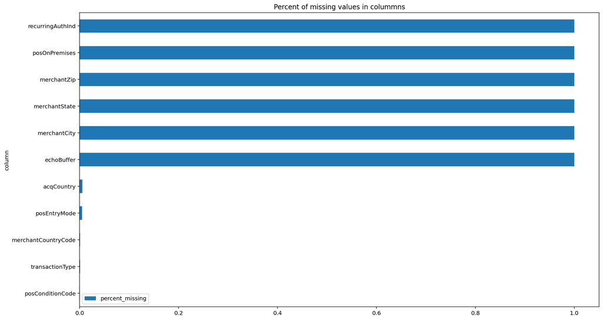

```python
plot_missing_values(card)
```

```python
## remove those column with all null values
null_summary = card.isnull().sum()
all_null_cols = [c for c in card.columns if null_summary[c]==len(card)]
```

```python
all_null_cols
```

```
['echoBuffer',
 'merchantCity',
 'merchantState',
 'merchantZip',
 'posOnPremises',
 'recurringAuthInd']
```

```python
card = card.drop(columns=all_null_cols)
```

#### clean the data - remove duplicated columns

```python
# check if there are different values between accountNumber and customerId
is_same = "Yes" if (card['accountNumber']!=card['customerId']).any() else "No"
print("Are there any different value between accountNumber and customerId? ",is_same)
```

```
Are there any different value between accountNumber and customerId?  No
```

```python
# remove field accountNumber, keep customerID
card.drop(columns="accountNumber",inplace=True)
```

#### clean the data - save current data

```python
# save to feather format for future use
# Feather format is almost the same format that it lives in RAM, so it is ridiculously fast to read and write
card.to_feather('data/transactions-cln')
```

```python
# read the feather data back
card = pd.read_feather('data/transactions-cln')
```

#### Answers - check the stats for numeric, datetime and bolean variables

(Be sure to include a count of null, minimum, maximum, and unique values where appropriate)

1. Numeric features
   - creditLimit (will be converted to category later since it is not continous variable): the minimum is 250 and maximum is 50000 dollars; There is no null values for creditLimit; The 3 most common credit limit amount are: 5000,15000,7500 dollars.
   - availableMoney: the minimum is -1005.6 dollars and maximum 50000 dollars (the same with max credit Limit); No null values for availableMoney. The average amount is around 6250 while the median amount is 3184, suggesting that the distribution is right skewed.
   - transactionAmount: the minumum amount is 0 dollars (even if remove those ADDRESS_VERIFICATION transactions) and the maximum is 2011.5 dollars. No null values for transactionAmount. The average transaction amount is near 137 and median amount is 88. Again, it is distributed right skewed.
   - currentBalance: the minimum balance is 0 and maximum is 47498.8 dollars. No null values.
2. Datetime features
   - transactionDateTime: it looks like the dataset represents the transactions in the whole year of 2016 (exclude the last day 12-31). No null values for this field.
   - currentExpDate: the cards expiration dates span from 12/31/2019 to 08/31/2033. No null values.
   - accountOpenDate: the open dates can range from 08/22/1989 to 12/31/2015. No null values.
   - dateOfLastAddressChange: the dates range of users changed their credit card address was from 08/22/1989 to 12/30/2016. No null values found.
3. Boolean features
   - cardPresent, expirationDateKeyinMatch and isFraud: they all have values either True or False. No null values found in those fields.
   - There are 12417 transactions were fraudulent that is around 1.6% of total 786363 transactions
4. Target field (isFraud)
   - 98.4% of the transactions are not fraud, which suggests that the it is an imbalanced dataset and need to deal with that in model traing.

```python
# get the basic stats for each field
display_all(card.describe(include="all"))
```

|  | customerId | creditLimit | availableMoney | transactionDateTime | transactionAmount | merchantName | acqCountry | merchantCountryCode | posEntryMode | posConditionCode | merchantCategoryCode | currentExpDate | accountOpenDate | dateOfLastAddressChange | cardCVV | enteredCVV | cardLast4Digits | transactionType | currentBalance | cardPresent | expirationDateKeyInMatch | isFraud |
| --- | --- | --- | --- | --- | --- | --- | --- | --- | --- | --- | --- | --- | --- | --- | --- | --- | --- | --- | --- | --- | --- | --- |
| count | 786363 | 786363.000000 | 786363.000000 | 786363 | 786363.000000 | 786363 | 781801 | 785639 | 782309 | 785954 | 786363 | 786363 | 786363 | 786363 | 786363 | 786363 | 786363 | 785665 | 786363.000000 | 786363 | 786363 | 786363 |
| unique | 5000 | NaN | NaN | 776637 | NaN | 2490 | 4 | 4 | 5 | 3 | 19 | 165 | 1820 | 2184 | 899 | 976 | 5246 | 3 | NaN | 2 | 2 | 2 |
| top | 380680241 | NaN | NaN | 2016-05-28 14:24:41 | NaN | Uber | US | US | 05 | 01 | online_retail | 2029-03-31 00:00:00 | 2014-06-21 00:00:00 | 2016-03-15 00:00:00 | 869 | 869 | 593 | PURCHASE | NaN | False | False | False |
| freq | 32850 | NaN | NaN | 4 | NaN | 25613 | 774709 | 778511 | 315035 | 628787 | 202156 | 5103 | 33623 | 3819 | 33749 | 33424 | 32946 | 745193 | NaN | 433495 | 785320 | 773946 |
| first | NaN | NaN | NaN | 2016-01-01 00:01:02 | NaN | NaN | NaN | NaN | NaN | NaN | NaN | 2019-12-31 00:00:00 | 1989-08-22 00:00:00 | 1989-08-22 00:00:00 | NaN | NaN | NaN | NaN | NaN | NaN | NaN | NaN |
| last | NaN | NaN | NaN | 2016-12-30 23:59:45 | NaN | NaN | NaN | NaN | NaN | NaN | NaN | 2033-08-31 00:00:00 | 2015-12-31 00:00:00 | 2016-12-30 00:00:00 | NaN | NaN | NaN | NaN | NaN | NaN | NaN | NaN |
| mean | NaN | 10759.464459 | 6250.725369 | NaN | 136.985791 | NaN | NaN | NaN | NaN | NaN | NaN | NaN | NaN | NaN | NaN | NaN | NaN | NaN | 4508.739089 | NaN | NaN | NaN |
| std | NaN | 11636.174890 | 8880.783989 | NaN | 147.725569 | NaN | NaN | NaN | NaN | NaN | NaN | NaN | NaN | NaN | NaN | NaN | NaN | NaN | 6457.442067 | NaN | NaN | NaN |
| min | NaN | 250.000000 | -1005.630005 | NaN | 0.000000 | NaN | NaN | NaN | NaN | NaN | NaN | NaN | NaN | NaN | NaN | NaN | NaN | NaN | 0.000000 | NaN | NaN | NaN |
| 25% | NaN | 5000.000000 | 1077.420044 | NaN | 33.650002 | NaN | NaN | NaN | NaN | NaN | NaN | NaN | NaN | NaN | NaN | NaN | NaN | NaN | 689.909973 | NaN | NaN | NaN |
| 50% | NaN | 7500.000000 | 3184.860107 | NaN | 87.900002 | NaN | NaN | NaN | NaN | NaN | NaN | NaN | NaN | NaN | NaN | NaN | NaN | NaN | 2451.760010 | NaN | NaN | NaN |
| 75% | NaN | 15000.000000 | 7500.000000 | NaN | 191.479996 | NaN | NaN | NaN | NaN | NaN | NaN | NaN | NaN | NaN | NaN | NaN | NaN | NaN | 5291.094971 | NaN | NaN | NaN |
| max | NaN | 50000.000000 | 50000.000000 | NaN | 2011.540039 | NaN | NaN | NaN | NaN | NaN | NaN | NaN | NaN | NaN | NaN | NaN | NaN | NaN | 47498.808594 | NaN | NaN | NaN |

```python
# only keep one transaction record for each card of each account, then check teh credit limit distribution
creditLimit_type = card.drop_duplicates(subset=["customerId","cardLast4Digits","creditLimit"])
creditLimit_type.creditLimit.value_counts()
```

```
5000.0     1538
15000.0    1114
7500.0     1101
10000.0     734
2500.0      729
20000.0     704
250.0       398
1000.0      369
50000.0     358
500.0       335
Name: creditLimit, dtype: int64
```

```python
# check number of null values of each field
card.isnull().sum()
```

```
customerId                     0
creditLimit                    0
availableMoney                 0
transactionDateTime            0
transactionAmount              0
merchantName                   0
acqCountry                  4562
merchantCountryCode          724
posEntryMode                4054
posConditionCode             409
merchantCategoryCode           0
currentExpDate                 0
accountOpenDate                0
dateOfLastAddressChange        0
cardCVV                        0
enteredCVV                     0
cardLast4Digits                0
transactionType              698
currentBalance                 0
cardPresent                    0
expirationDateKeyInMatch       0
isFraud                        0
dtype: int64
```

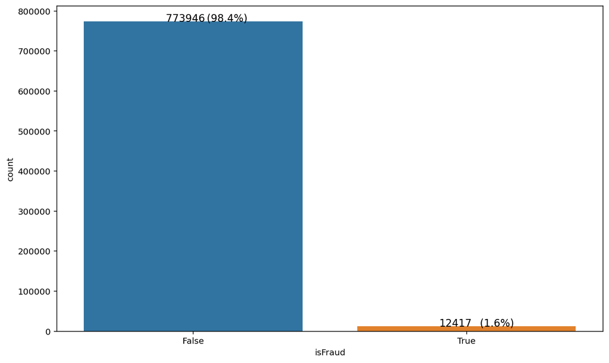

```python
# the count of fraud and non fraud transactions
plt.figure(figsize=(10,6))
ax=sns.countplot(x="isFraud",data=card)
addValue_withoutHue(ax,card.isFraud)
```

#### Answers - check the stats for categorical variables

1. Categorical features (add 1 new feature, norm_merchantName, which is normalized merchantName make chain stores the same name)
   - the merchanName has 2490 unique values and 0 null values. But I found out the merchant chain stores will have different values with the same brand name but different number (for example AMC #). I will normalize them (remove "#XXXX') and create new feature norm_merchantName.
   - echoBuffer,merchantCity,merchantState,merchantZip,posOnPremises,recurringAuthInd: they are the features that all values are null.
   - the stats of other categorical features are printed below.

```python
# normalize merchantName by removing the trailing number identifier "#XXXXX"
card["reg_merchantName"] = card["merchantName"].apply(lambda x:re.sub(r"\ \#.+","",x))
```

```python
for c in ["acqCountry","merchantCountryCode","posEntryMode","posConditionCode","merchantCategoryCode","transactionType"]:
    print(f"the field {c} has {card[c].nunique()} unique values, which are {card[c].value_counts().index.tolist()}")
    print(f"the field {c} has {card[c].isnull().sum()} null values")
    print("--------------------------------------------")
```

```
the field acqCountry has 4 unique values, which are ['US', 'MEX', 'CAN', 'PR']
the field acqCountry has 4562 null values
--------------------------------------------
the field merchantCountryCode has 4 unique values, which are ['US', 'MEX', 'CAN', 'PR']
the field merchantCountryCode has 724 null values
--------------------------------------------
the field posEntryMode has 5 unique values, which are ['05', '09', '02', '90', '80']
the field posEntryMode has 4054 null values
--------------------------------------------
the field posConditionCode has 3 unique values, which are ['01', '08', '99']
the field posConditionCode has 409 null values
--------------------------------------------
the field merchantCategoryCode has 19 unique values, which are ['online_retail', 'fastfood', 'entertainment', 'food', 'online_gifts', 'rideshare', 'hotels', 'fuel', 'subscriptions', 'auto', 'health', 'personal care', 'airline', 'mobileapps', 'online_subscriptions', 'furniture', 'food_delivery', 'gym…
the field merchantCategoryCode has 0 null values
--------------------------------------------
the field transactionType has 3 unique values, which are ['PURCHASE', 'REVERSAL', 'ADDRESS_VERIFICATION']
the field transactionType has 698 null values
--------------------------------------------
```

```python
for c in ['merchantName','cardCVV','enteredCVV','cardLast4Digits','reg_merchantName']:
    print(f"the field {c} has {card[c].nunique()} unqiue values")
    print(f"the field {c} has {card[c].isnull().sum()} null values")
    print("--------------------------------------------")
```

```
the field merchantName has 2490 unqiue values
the field merchantName has 0 null values
--------------------------------------------
the field cardCVV has 899 unqiue values
the field cardCVV has 0 null values
--------------------------------------------
the field enteredCVV has 976 unqiue values
the field enteredCVV has 0 null values
--------------------------------------------
the field cardLast4Digits has 5246 unqiue values
the field cardLast4Digits has 0 null values
--------------------------------------------
the field reg_merchantName has 205 unqiue values
the field reg_merchantName has 0 null values
--------------------------------------------
```

# Question 2: Plot

### 2.1 Plot a histogram of the processed amounts of each transaction, the transactionAmount column.

The transaction amount follows exponential distribution (right skewed), meaning there are fewer large values and more small values.

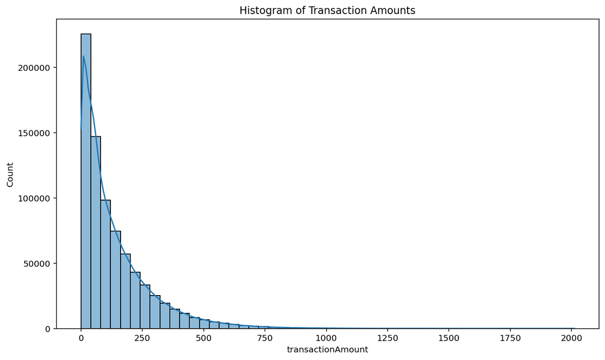

```python
plt.figure(figsize=(10,6))
sns.histplot(data = card, x="transactionAmount", kde=True, bins=50)

# add title
plt.title('Histogram of Transaction Amounts')
```

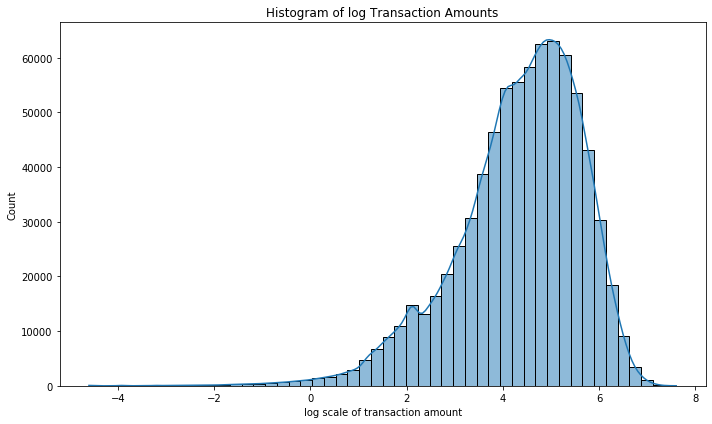

```python
# after log transformation on transactionAmount, the distribution is apporaching normal distribution.
log_amount = card.query("transactionAmount!=0")

log_amount['transactionAmount'] =np.log(log_amount['transactionAmount'])

plt.figure(figsize=(10,6))
sns.histplot(data = log_amount, x="transactionAmount", kde=True, bins=50)

# add title
plt.xlabel("log scale of transaction amount")
plt.title('Histogram of log Transaction Amounts')
log_scale=True
```

### 2.2 Report any structure you find and any hypotheses you have about that structure.

#### Answers - Hypothesis1 and ttest: fraud transaction amount is equal to non fraud on average

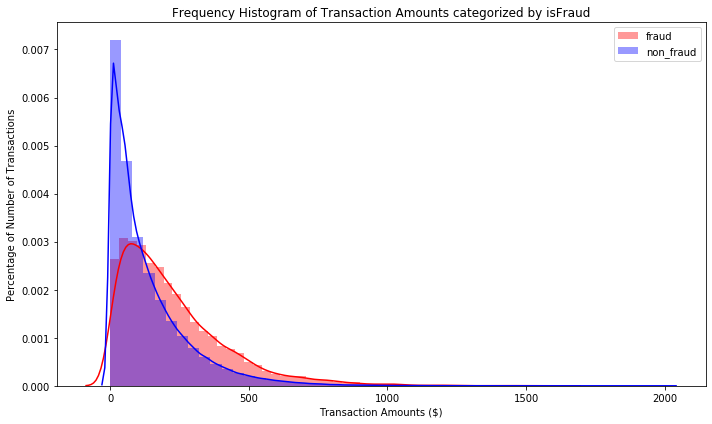

```python
# seaborn histogram of Transaction Amounts categorized by isFraud

fraud = card.loc[card.isFraud==True, 'transactionAmount']
non_fraud = card.loc[card.isFraud==False, 'transactionAmount']

plt.figure(figsize=(10,6))
sns.distplot(fraud , color="red", label="fraud")
sns.distplot(non_fraud , color="blue", label="non_fraud")
plt.title('Frequency Histogram of Transaction Amounts categorized by isFraud')
plt.xlabel('Transaction Amounts ($)')
plt.ylabel('Percentage of Number of Transactions')
plt.legend();
```

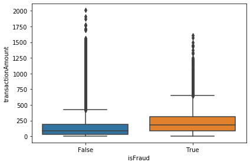

```python
sns.boxplot(x='isFraud', y='transactionAmount', data=card)
```

```python
print("the average of transaction amount for fraud is: {}".format(fraud.mean()))
print("the average of transaction amount for non fraud is: {}".format(non_fraud.mean()))
```

```
the average of transaction amount for fraud is: 225.2158203125
the average of transaction amount for non fraud is: 135.5675506591797
```

```python
ttest_res = ttest_ind(fraud,non_fraud,equal_var=False)
```

```python
print("t statistic is {} with p value {}".format(ttest_res.statistic,ttest_res.pvalue))
print("---------------------------------")
if_sig = "significant" if ttest_res.pvalue<0.05 else "not significant"
print("The difference is",if_sig)
```

```
t statistic is 52.44918963207227 with p value 0.0
---------------------------------
The difference is significant
```

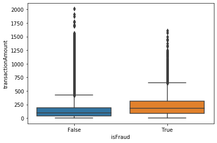

```python
# check disribution only for PURCHASE transaction type ,similar result from above
purchase = card[card.transactionType=="PURCHASE"]
sns.boxplot(x='isFraud', y='transactionAmount', data=purchase)
```

#### Answers - Hypothesis 2 and ttest: The average transaction amounts among all merchant categories are equal

- Reject hypothesis: The average transaction amount among different merchant categories are different
- by comparing each pair of merchant categories, I found that mobileApps(5.8 dollars), online_subscriptions(14.5 dollars) and gym(33.4 dollars) are the three categories have the lowest average transaction amount, while personal care(147.5), subscriptions (146.9) and rideshare(146.2) are the three with the most average amount.
- this conclusion is in line with our common knowledge

```python
import statsmodels.api as sm
```

```python
# the f-stats and p value indicate that the amount among diffrent merchant categories are different.
lin_reg = sm.OLS(log_amount['transactionAmount'], log_amount['merchantCategoryCode'].cat.codes).fit()
print(lin_reg.summary())
```

```
                                 OLS Regression Results
=======================================================================================
Dep. Variable:      transactionAmount   R-squared (uncentered):                   0.695
Model:                            OLS   Adj. R-squared (uncentered):              0.695
Method:                 Least Squares   F-statistic:                          1.739e+06
Date:                Sat, 24 Apr 2021   Prob (F-statistic):                        0.00
Time:                        15:18:46   Log-Likelihood:                     -1.7842e+06
No. Observations:              764138   AIC:                                  3.568e+06
Df Residuals:                  764137   BIC:                                  3.569e+06
Df Model:                           1
Covariance Type:            nonrobust
==============================================================================
                 coef    std err          t      P>|t|      [0.025      0.975]
------------------------------------------------------------------------------
x1             0.3430      0.000   1318.661      0.000       0.343       0.344
==============================================================================
Omnibus:                    19273.598   Durbin-Watson:                   1.094
Prob(Omnibus):                  0.000   Jarque-Bera (JB):            10349.102
Skew:                          -0.091   Prob(JB):                         0.00
Kurtosis:                       2.460   Cond. No.                         1.00
==============================================================================

Warnings:
[1] Standard Errors assume that the covariance matrix of the errors is correctly specified.
```

```python
# the paired comparison of differnt merchant categories on average transaction amount
# if reject if true, it means there is significant difference
mc = statsmodels.stats.multicomp.MultiComparison(card['transactionAmount'],card['merchantCategoryCode'])
mc_results = mc.tukeyhsd()
print(mc_results)
```

```
                 Multiple Comparison of Means - Tukey HSD, FWER=0.05
=====================================================================================
       group1               group2         meandiff p-adj    lower     upper   reject
-------------------------------------------------------------------------------------
             airline                 auto   -0.1122    0.9   -5.4676    5.2431  False
             airline          cable/phone  -47.6686  0.001  -61.9371     -33.4   True
             airline        entertainment    1.0851    0.9   -3.3845    5.5547  False
             airline             fastfood    0.6349    0.9   -3.7305    5.0003  False
             airline                 food    0.3573    0.9   -4.1343    4.8489  False
             airline        food_delivery  -91.8007  0.001   -99.533  -84.0683   True
             airline                 fuel  -99.7758  0.001  -105.025  -94.5267   True
             airline            furniture   -0.0309    0.9   -7.2071    7.1452  False
             airline                  gym -111.4903  0.001 -123.0508  -99.9299   True
             airline               health    0.7495    0.9   -4.7531    6.2521  False
             airline               hotels    0.6285    0.9   -4.3037    5.5607  False
             airline           mobileapps -139.1194  0.001 -144.9486 -133.2902   True
             airline         online_gifts    1.1694    0.9    -3.375    5.7139  False
             airline        online_retail     0.275    0.9   -3.9713    4.5213  False
             airline online_subscriptions -130.3777  0.001  -136.709 -124.0464   True
             airline        personal care    2.5603    0.9   -2.9506    8.0711  False
             airline            rideshare    1.2642    0.9   -3.4052    5.9336  False
             airline        subscriptions    1.9441    0.9   -3.3502    7.2383  False
                auto          cable/phone  -47.5563  0.001  -61.6547  -33.4579   True
                auto        entertainment    1.1973    0.9    -2.695    5.0896  False
                auto             fastfood    0.7471    0.9    -3.025    4.5192  False
                auto                 food    0.4695    0.9   -3.4479     4.387  False
                auto        food_delivery  -91.6884  0.001   -99.102  -84.2748   True
                auto                 fuel  -99.6636  0.001 -104.4307  -94.8965   True
                auto            furniture    0.0813    0.9   -6.7502    6.9128  False
                auto                  gym -111.3781  0.001 -122.7278 -100.0284   True
                auto               health    0.8617    0.9   -4.1831    5.9066  False
                auto               hotels    0.7407    0.9   -3.6751    5.1564  False
                auto           mobileapps -139.0072  0.001 -144.4064  -133.608   True
                auto         online_gifts    1.2817    0.9   -2.6963    5.2596  False
                auto        online_retail    0.3872    0.9   -3.2464    4.0209  False
                auto online_subscriptions -130.2655  0.001 -136.2033 -124.3277   True
                auto        personal care    2.6725    0.9   -2.3814    7.7264  False
                auto            rideshare    1.3764    0.9   -2.7437    5.4965  False
                auto        subscriptions    2.0563    0.9   -2.7605     6.873  False
         cable/phone        entertainment   48.7536  0.001   34.9673   62.5399   True
```

[output cut: 121 more lines]

```
        online_gifts online_subscriptions -131.5471  0.001 -136.7653 -126.3289   True
        online_gifts        personal care    1.3908    0.9   -2.7941    5.5758  False
        online_gifts            rideshare    0.0947    0.9   -2.8965     3.086  False
        online_gifts        subscriptions    0.7746    0.9   -3.1207    4.6699  False
       online_retail online_subscriptions -130.6527  0.001 -135.6134  -125.692   True
       online_retail        personal care    2.2852 0.8231   -1.5739    6.1444  False
       online_retail            rideshare    0.9892    0.9   -1.5262    3.5045  False
       online_retail        subscriptions     1.669    0.9   -1.8739     5.212  False
online_subscriptions        personal care   132.938  0.001  126.8595  139.0164   True
online_subscriptions            rideshare  131.6419  0.001  126.3145  136.9693   True
online_subscriptions        subscriptions  132.3218  0.001   126.439  138.2045   True
       personal care            rideshare   -1.2961    0.9   -5.6164    3.0242  False
       personal care        subscriptions   -0.6162    0.9   -5.6053    4.3729  False
           rideshare        subscriptions    0.6799    0.9   -3.3605    4.7203  False
-------------------------------------------------------------------------------------
```

```python
merchant_trAmt = card.groupby("merchantCategoryCode").apply(lambda x:pd.Series({"amt":x['transactionAmount'].mean()}))
```

```python
# average amount of each merchant category
merchant_trAmt.sort_values(by="amt",ascending=False)#.plot(kind="bar")
```

| merchantCategoryCode | amt |
| --- | --- |
| personal care | 147.516877 |
| subscriptions | 146.900673 |
| rideshare | 146.220783 |
| online_gifts | 146.126042 |
| entertainment | 146.041694 |
| health | 145.706099 |
| fastfood | 145.591507 |
| hotels | 145.585076 |
| food | 145.313906 |
| online_retail | 145.231632 |
| airline | 144.956619 |
| furniture | 144.925686 |
| auto | 144.844389 |
| cable/phone | 97.288068 |
| food_delivery | 53.155968 |
| fuel | 45.180771 |
| gym | 33.466315 |
| online_subscriptions | 14.578915 |
| mobileapps | 5.837203 |

#### Answers - observation 1: The fraud average transaction amounts are larger than non fraudulent amounts across differnt merchanat categories

```python
merchant_trAmt_frd = card.groupby(["merchantCategoryCode","isFraud"]).apply(lambda x:pd.Series({"amt":x['transactionAmount'].mean()})).reset_index()#.fillna(0)#.unstack(fill_value=0)
```

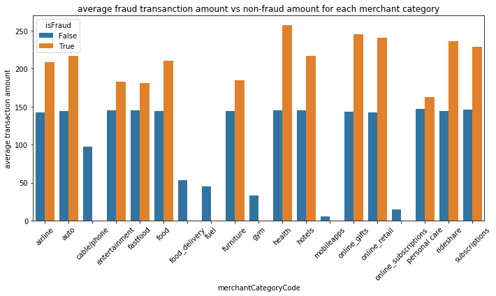

```python
plt.figure(figsize=(10,6))
sns.barplot(x='merchantCategoryCode',y='amt',hue='isFraud',data=merchant_trAmt_frd)
plt.xticks(rotation = 45) # Rotates X-Axis Ticks by 45-degrees
plt.title("average fraud transanction amount vs non-fraud amount for each merchant category")
plt.ylabel("average transaction amount")
```

#### Answers - Hypothesis 3 and ttest: The average transaction amounts among all merchant countries are equal

- Accept hypothesis: The average transaction amount among different merchant countries are no different

```python
card_merchantCountry = card[["merchantCountryCode","acqCountry",'transactionAmount','isFraud']].fillna("others")
```

```python
mc_cty = statsmodels.stats.multicomp.MultiComparison(card_merchantCountry['transactionAmount'],card_merchantCountry['merchantCountryCode'])
mc_cty_results = mc_cty.tukeyhsd()
print(mc_cty_results)
```

```
 Multiple Comparison of Means - Tukey HSD, FWER=0.05
=====================================================
group1 group2 meandiff p-adj   lower    upper  reject
-----------------------------------------------------
   CAN    MEX   0.5542    0.9 -10.3359 11.4444  False
   CAN     PR  -3.6531    0.9 -16.7331  9.4269  False
   CAN     US  -0.8395    0.9  -9.0334  7.3544  False
   CAN others   0.8141    0.9 -16.2508 17.8789  False
   MEX     PR  -4.2073 0.8836   -16.69  8.2754  False
   MEX     US  -1.3937    0.9  -8.5959  5.8085  False
   MEX others   0.2598    0.9 -16.3516 16.8713  False
    PR     US   2.8136    0.9  -7.4022 13.0294  False
    PR others   4.4672    0.9 -13.6555 22.5899  False
    US others   1.6536    0.9 -13.3293 16.6364  False
-----------------------------------------------------
```

when the acqCountry is different from merchant coutnry, will the average transaction amount be differnt than those that the countries are same?

```python
card_merchantCountry['cntry_diff']=card_merchantCountry["merchantCountryCode"]==card_merchantCountry['acqCountry']
```

```python
card_merchantCountry.cntry_diff.value_counts()
```

```
True     782452
False      3911
Name: cntry_diff, dtype: int64
```

```python
ttest(card_merchantCountry,"cntry_diff",'transactionAmount')
```

```
t statistic is -0.16915828730675664 with p value 0.8656721823157648
---------------------------------
The difference is not significant
```

# Question 3: Data Wrangling - Duplicate Transactions

```python
card_wr = card.sort_values(by=['customerId','cardLast4Digits','transactionDateTime']).reset_index(drop=True)
```

```python
card_wr.head()
```

|  | customerId | creditLimit | availableMoney | transactionDateTime | transactionAmount | merchantName | acqCountry | merchantCountryCode | posEntryMode | posConditionCode | merchantCategoryCode | currentExpDate | accountOpenDate | dateOfLastAddressChange | cardCVV | enteredCVV | cardLast4Digits | transactionType | currentBalance | cardPresent | expirationDateKeyInMatch | isFraud | reg_merchantName |
| --- | --- | --- | --- | --- | --- | --- | --- | --- | --- | --- | --- | --- | --- | --- | --- | --- | --- | --- | --- | --- | --- | --- | --- |
| 0 | 100088067 | 50000.0 | 49748.441406 | 2016-01-17 15:41:46 | 378.670013 | Mobile eCards | US | US | 05 | 01 | online_gifts | 2031-11-30 | 2014-01-09 | 2014-01-09 | 402 | 402 | 2077 | PURCHASE | 251.559998 | False | False | False | Mobile eCards |
| 1 | 100088067 | 50000.0 | 49792.328125 | 2016-02-08 06:09:12 | 259.440002 | Blue Mountain eCards | US | US | 05 | 01 | online_gifts | 2028-01-31 | 2014-01-09 | 2014-01-09 | 402 | 402 | 2077 | PURCHASE | 207.669998 | False | False | False | Blue Mountain eCards |
| 2 | 100088067 | 50000.0 | 49532.890625 | 2016-02-09 18:36:53 | 32.500000 | EZ Putt Putt #804489 | US | US | 09 | 01 | entertainment | 2026-07-31 | 2014-01-09 | 2014-01-09 | 402 | 402 | 2077 | PURCHASE | 467.109985 | True | False | False | EZ Putt Putt |
| 3 | 100088067 | 50000.0 | 49477.328125 | 2016-02-13 20:17:41 | 56.049999 | Fresh Flowers | US | US | 05 | 01 | online_gifts | 2033-01-31 | 2014-01-09 | 2014-01-09 | 402 | 402 | 2077 | PURCHASE | 522.669983 | False | False | False | Fresh Flowers |
| 4 | 100088067 | 50000.0 | 49923.921875 | 2016-03-12 12:55:28 | 97.790001 | Dinosaur Sandwitch Bar #960325 | US | US | 05 | 01 | food | 2032-01-31 | 2014-01-09 | 2014-01-09 | 402 | 402 | 2077 | PURCHASE | 76.080002 | True | False | False | Dinosaur Sandwitch Bar |

### 3.1 Can you programmatically identify reversed and multi-swipe transactions?

#### Answers - identify reversed transanctions

"REVERSAL" transaction observations:

1. Each "REVERSAL" transaction has a paired normal "PURCHASE" with the same accountNumber, transactionAmount and merchantName
2. In this dataset, it looks like the "REVERSAL" can happen right after its paired PURCHASE or a few days later
3. The availableMoney of next transaction should be equal to "REVERSAL" availableMoney+ "REVERSAL" transactionAmount

To identify reversal transactions:

1. Take advantage of the purchaseType field: Select data with transactionType == "REVERSAL"
2. When the purchaseType is NULL: Try to infer if it is REVERSAL by the rules from the previous transaction obervations

```python
# REVERSAL and PURCHASE happened on same day
card_wr.query("customerId=='100088067' and merchantName=='AMC #79863' and currentExpDate=='2020-06-30'")
```

|  | customerId | creditLimit | availableMoney | transactionDateTime | transactionAmount | merchantName | acqCountry | merchantCountryCode | posEntryMode | posConditionCode | merchantCategoryCode | currentExpDate | accountOpenDate | dateOfLastAddressChange | cardCVV | enteredCVV | cardLast4Digits | transactionType | currentBalance | cardPresent | expirationDateKeyInMatch | isFraud | reg_merchantName |
| --- | --- | --- | --- | --- | --- | --- | --- | --- | --- | --- | --- | --- | --- | --- | --- | --- | --- | --- | --- | --- | --- | --- | --- |
| 65 | 100088067 | 50000.0 | 49834.199219 | 2016-11-20 07:57:05 | 22.32 | AMC #79863 | US | US | 09 | 01 | entertainment | 2020-06-30 | 2014-01-09 | 2014-01-09 | 546 | 546 | 4615 | PURCHASE | 165.800003 | True | False | False | AMC |
| 66 | 100088067 | 50000.0 | 49811.878906 | 2016-11-20 08:00:04 | 22.32 | AMC #79863 | US | US | 09 | 01 | entertainment | 2020-06-30 | 2014-01-09 | 2014-01-09 | 546 | 546 | 4615 | REVERSAL | 188.119995 | True | False | False | AMC |

```python
# REVERSAL and PURCHASE happened on different days
card_wr.query("customerId=='101380713' and merchantName=='staples.com' and currentExpDate=='2031-12-31'")# and merchantName=='AMC #79863' and posEntryMode=='09'")
```

|  | customerId | creditLimit | availableMoney | transactionDateTime | transactionAmount | merchantName | acqCountry | merchantCountryCode | posEntryMode | posConditionCode | merchantCategoryCode | currentExpDate | accountOpenDate | dateOfLastAddressChange | cardCVV | enteredCVV | cardLast4Digits | transactionType | currentBalance | cardPresent | expirationDateKeyInMatch | isFraud | reg_merchantName |
| --- | --- | --- | --- | --- | --- | --- | --- | --- | --- | --- | --- | --- | --- | --- | --- | --- | --- | --- | --- | --- | --- | --- | --- |
| 666 | 101380713 | 10000.0 | 5279.100098 | 2016-09-23 18:39:37 | 303.720001 | staples.com | US | US | 02 | 08 | online_retail | 2031-12-31 | 2015-06-01 | 2016-08-28 | 551 | 551 | 7553 | PURCHASE | 4720.899902 | False | False | False | staples.com |
| 671 | 101380713 | 10000.0 | 4433.970215 | 2016-10-18 06:54:33 | 303.720001 | staples.com | US | US | 02 | 08 | online_retail | 2031-12-31 | 2015-06-01 | 2016-08-28 | 551 | 551 | 7553 | REVERSAL | 5566.029785 | False | False | False | staples.com |

```python
# define related columns
rev_cols = ["customerId","transactionAmount","reg_merchantName"]
t_type = ["transactionType"]
```

```python
# get transanctions with transactionType is equal to REVERSAL
card_reversal = card_wr.query("transactionType=='REVERSAL'")
```

```python
card_reversal.head()
```

|  | customerId | creditLimit | availableMoney | transactionDateTime | transactionAmount | merchantName | acqCountry | merchantCountryCode | posEntryMode | posConditionCode | merchantCategoryCode | currentExpDate | accountOpenDate | dateOfLastAddressChange | cardCVV | enteredCVV | cardLast4Digits | transactionType | currentBalance | cardPresent | expirationDateKeyInMatch | isFraud | reg_merchantName |
| --- | --- | --- | --- | --- | --- | --- | --- | --- | --- | --- | --- | --- | --- | --- | --- | --- | --- | --- | --- | --- | --- | --- | --- |
| 66 | 100088067 | 50000.0 | 49811.878906 | 2016-11-20 08:00:04 | 22.320000 | AMC #79863 | US | US | 09 | 01 | entertainment | 2020-06-30 | 2014-01-09 | 2014-01-09 | 546 | 546 | 4615 | REVERSAL | 188.119995 | True | False | False | AMC |
| 95 | 100328049 | 5000.0 | 4605.100098 | 2016-01-15 20:36:18 | 43.740002 | Lyft | US | US | 09 | 08 | rideshare | 2027-05-31 | 2014-01-07 | 2014-01-07 | 206 | 206 | 2941 | REVERSAL | 394.899994 | False | False | False | Lyft |
| 103 | 100328049 | 5000.0 | 3792.090088 | 2016-03-26 17:35:09 | 284.970001 | McDonalds #423357 | US | US | 02 | 08 | fastfood | 2027-10-31 | 2014-01-07 | 2014-01-07 | 206 | 206 | 2941 | REVERSAL | 1207.910034 | True | False | False | McDonalds |
| 305 | 100737756 | 250.0 | 119.510002 | 2016-06-06 22:56:52 | 93.669998 | 34th BBQ #436606 | US | US | 05 | 01 | food | 2026-05-31 | 2015-06-21 | 2015-06-21 | 463 | 463 | 4317 | REVERSAL | 130.490005 | True | False | False | 34th BBQ |
| 347 | 100737756 | 250.0 | 144.520004 | 2016-08-24 20:21:19 | 501.290009 | Best Bistro #262998 | US | US | 05 | 01 | food | 2021-07-31 | 2015-06-21 | 2015-06-21 | 463 | 463 | 4317 | REVERSAL | 105.480003 | True | False | False | Best Bistro |

try to see if there are any transactions with type is **Null** but can be **inferred with "REVERSAL" or "PURCHASE" type** based on observations

```python
# get all the accountNumber with at least one null transactionType
type_with_null = card_wr.groupby("customerId").apply(lambda x:pd.Series({"null_count":x.transactionType.isnull().sum()}))
type_with_null = type_with_null[type_with_null["null_count"]>0]
```

```python
# get all the transactions of those accountNumber
card_trans_null = card_wr.loc[card_wr.customerId.isin(type_with_null.index.tolist()),rev_cols+t_type]
```

```python
card_trans_null.head()
```

|  | customerId | transactionAmount | reg_merchantName | transactionType |
| --- | --- | --- | --- | --- |
| 1530 | 102204865 | 348.119995 | Subway | PURCHASE |
| 1531 | 102204865 | 38.639999 | Rodeway Inn | PURCHASE |
| 1532 | 102204865 | 165.639999 | 1st Sandwitch Bar | PURCHASE |
| 1533 | 102204865 | 238.410004 | Hilton Hotels | PURCHASE |
| 1534 | 102204865 | 39.340000 | Ricks Repair | PURCHASE |

```python
# create a new column that flag the null transactionType
card_trans_null['is_typeNull']=card_trans_null.transactionType.isnull()

# based on rules from observations, create columns
card_trans_null['trans_cnt']=card_trans_null.groupby(rev_cols)\
                        ['transactionType'].transform('size')
card_trans_null['is_null_sum']=card_trans_null.groupby(rev_cols)\
                    ['is_typeNull'].transform(sum)

# query those null transaction type that is inferred to be REVERSAL
trans_null_reversal = card_trans_null.query('trans_cnt>1 & is_null_sum>0')
```

```python
trans_null_reversal.sort_values(["customerId","transactionAmount"])
```

|  | customerId | transactionAmount | reg_merchantName | transactionType | is_typeNull | trans_cnt | is_null_sum |
| --- | --- | --- | --- | --- | --- | --- | --- |
| 24896 | 132629755 | 55.599998 | cheapfast.com | NaN | True | 2 | 1.0 |
| 25093 | 132629755 | 55.599998 | cheapfast.com | REVERSAL | False | 2 | 1.0 |
| 66229 | 191623743 | 114.330002 | sears.com | NaN | True | 2 | 2.0 |
| 66230 | 191623743 | 114.330002 | sears.com | NaN | True | 2 | 2.0 |
| 66704 | 191896180 | 140.059998 | cheapfast.com | NaN | True | 2 | 2.0 |
| ... | ... | ... | ... | ... | ... | ... | ... |
| 743532 | 941631553 | 87.849998 | Merchants Tire | REVERSAL | False | 2 | 1.0 |
| 749074 | 948561932 | 81.379997 | gap.com | NaN | True | 2 | 1.0 |
| 749103 | 948561932 | 81.379997 | gap.com | REVERSAL | False | 2 | 1.0 |
| 753870 | 952929763 | 70.220001 | alibaba.com | NaN | True | 2 | 1.0 |
| 753871 | 952929763 | 70.220001 | alibaba.com | REVERSAL | False | 2 | 1.0 |

66 rows × 7 columns

For those paired transactions with one PUCHASE one NULL or two NULLs, I need to check if they are "PURCHASE" and "REVERSAL" or "PURCHASE" and "PURCHASE" (multi-swie)

```python
# null_fill will record index and the filled value
# null_rev_cnt is for count how many null value can be filled with REVERSAL
null_fill = {}
null_rev_cnt = 0
not_rev = []
for i,j in trans_null_reversal.groupby(rev_cols):
    lst = j.transactionType.values.tolist()
    #print(lst)
    d = j.is_typeNull.to_dict()

    if not "PURCHASE" in lst:
        for k,v in d.items():
            if v:
                null_fill[k]="PURCHASE"
                d.pop(k,None)
                break
    if not "REVERSAL" in lst:
        for k,v in d.items():
            if v:
                avl_dif = card_wr.loc[k+1,"availableMoney"]-card_wr.loc[k,"availableMoney"]
                if abs(card_wr.loc[k,'transactionAmount']-avl_dif)<0.1:
                #if avl_dif>=0:
                    null_fill[k]="REVERSAL"
                    null_rev_cnt+=1
                break
```

```python
print("how many null transanctionType might be filled REVERSAL? ",null_rev_cnt)
```

```
how many null transanctionType might be filled REVERSAL?  0
```

#### Answers - identify multi-swipe transanctions

multi-swipe transaction observations:  
The "multi-swipe" transactions should  
1. have transactionType be PURCHASE or NULL  
2. have same "transactionAmount, accountNumber, merchantName"  
3. have same "cardLast4Digits","cardCVV", since the same accountNumber might link to more than 1 credit cards  
4. happen within a short time span (i will define 60 seconds here), otherwise those Recurring Transactions & Subscriptions will be counted as well.

fill NULL of transactionType based on observations above

```python
card_wr.head()
```

|  | customerId | creditLimit | availableMoney | transactionDateTime | transactionAmount | merchantName | acqCountry | merchantCountryCode | posEntryMode | posConditionCode | merchantCategoryCode | currentExpDate | accountOpenDate | dateOfLastAddressChange | cardCVV | enteredCVV | cardLast4Digits | transactionType | currentBalance | cardPresent | expirationDateKeyInMatch | isFraud | reg_merchantName |
| --- | --- | --- | --- | --- | --- | --- | --- | --- | --- | --- | --- | --- | --- | --- | --- | --- | --- | --- | --- | --- | --- | --- | --- |
| 0 | 100088067 | 50000.0 | 49748.441406 | 2016-01-17 15:41:46 | 378.670013 | Mobile eCards | US | US | 05 | 01 | online_gifts | 2031-11-30 | 2014-01-09 | 2014-01-09 | 402 | 402 | 2077 | PURCHASE | 251.559998 | False | False | False | Mobile eCards |
| 1 | 100088067 | 50000.0 | 49792.328125 | 2016-02-08 06:09:12 | 259.440002 | Blue Mountain eCards | US | US | 05 | 01 | online_gifts | 2028-01-31 | 2014-01-09 | 2014-01-09 | 402 | 402 | 2077 | PURCHASE | 207.669998 | False | False | False | Blue Mountain eCards |
| 2 | 100088067 | 50000.0 | 49532.890625 | 2016-02-09 18:36:53 | 32.500000 | EZ Putt Putt #804489 | US | US | 09 | 01 | entertainment | 2026-07-31 | 2014-01-09 | 2014-01-09 | 402 | 402 | 2077 | PURCHASE | 467.109985 | True | False | False | EZ Putt Putt |
| 3 | 100088067 | 50000.0 | 49477.328125 | 2016-02-13 20:17:41 | 56.049999 | Fresh Flowers | US | US | 05 | 01 | online_gifts | 2033-01-31 | 2014-01-09 | 2014-01-09 | 402 | 402 | 2077 | PURCHASE | 522.669983 | False | False | False | Fresh Flowers |
| 4 | 100088067 | 50000.0 | 49923.921875 | 2016-03-12 12:55:28 | 97.790001 | Dinosaur Sandwitch Bar #960325 | US | US | 05 | 01 | food | 2032-01-31 | 2014-01-09 | 2014-01-09 | 402 | 402 | 2077 | PURCHASE | 76.080002 | True | False | False | Dinosaur Sandwitch Bar |

```python
# if transactionType is ADDRESS_VERIFICATION, the transactionAmount should be 0
print("How many NULL transaction type is ADDRESS_VERIFICATION? ",len(card_wr[(card_wr.transactionType.isnull()) & (card_wr.transactionAmount==0)]))
```

```
How many NULL transaction type is ADDRESS_VERIFICATION?  0
```

```python
"""
based on the inferences above (there are no REVERSAL or ADDRESS_VERIFICATION for NULL transactionType),
all the null values of transactionType should be filled with PURCHASE
"""
card_wr.transactionType.fillna("PURCHASE",inplace=True)
```

```python
print("are there anymore null values in transactionType? ",card_wr.transactionType.isnull().sum()!=0)
```

```
are there anymore null values in transactionType?  False
```

get multi-swipe

```python
card_wr.transactionType.value_counts()
```

```
PURCHASE                745891
REVERSAL                 20303
ADDRESS_VERIFICATION     20169
Name: transactionType, dtype: int64
```

```python
# define identified columns
multi_sw_cols = ["customerId","cardLast4Digits","merchantName","transactionAmount"]
```

```python
# get candidate transactions (transacType is PURCHASE)
multi_swipe = card_wr.query("transactionType=='PURCHASE'")
```

```python
multi_swipe.shape
```

```
(745891, 23)
```

```python
multi_swipe.info()
```

```
<class 'pandas.core.frame.DataFrame'>
Int64Index: 745891 entries, 0 to 786362
Data columns (total 23 columns):
 #   Column                    Non-Null Count   Dtype
---  ------                    --------------   -----
 0   customerId                745891 non-null  object
 1   creditLimit               745891 non-null  float64
 2   availableMoney            745891 non-null  float64
 3   transactionDateTime       745891 non-null  datetime64[ns]
 4   transactionAmount         745891 non-null  float64
 5   merchantName              745891 non-null  category
 6   acqCountry                741561 non-null  object
 7   merchantCountryCode       745202 non-null  object
 8   posEntryMode              742027 non-null  object
 9   posConditionCode          745502 non-null  object
 10  merchantCategoryCode      745891 non-null  category
 11  currentExpDate            745891 non-null  datetime64[ns]
 12  accountOpenDate           745891 non-null  datetime64[ns]
 13  dateOfLastAddressChange   745891 non-null  datetime64[ns]
 14  cardCVV                   745891 non-null  category
 15  enteredCVV                745891 non-null  category
 16  cardLast4Digits           745891 non-null  category
 17  transactionType           745891 non-null  object
 18  currentBalance            745891 non-null  float64
 19  cardPresent               745891 non-null  bool
 20  expirationDateKeyInMatch  745891 non-null  bool
 21  isFraud                   745891 non-null  bool
 22  reg_merchantName          745891 non-null  object
dtypes: bool(3), category(5), datetime64[ns](4), float64(4), object(7)
memory usage: 100.0+ MB
```

```python
# get multi-swipe candidates (including recurring&subscriptions) : duplicate transactions count bigger than 1
multi_swipe['dup_cnt'] = multi_swipe.groupby(multi_sw_cols,observed=True)['transactionType'].transform('size')
multi_swipe = multi_swipe.loc[multi_swipe.dup_cnt>1,multi_sw_cols+['transactionType','transactionDateTime']]
```

```python
multi_swipe.head()
```

|  | customerId | cardLast4Digits | merchantName | transactionAmount | transactionType | transactionDateTime |
| --- | --- | --- | --- | --- | --- | --- |
| 22 | 100088067 | 2077 | Fresh Flowers | 411.350006 | PURCHASE | 2016-10-16 18:01:00 |
| 23 | 100088067 | 2077 | Fresh Flowers | 411.350006 | PURCHASE | 2016-10-16 18:01:02 |
| 40 | 100088067 | 4615 | Apple iTunes | 3.960000 | PURCHASE | 2016-05-05 22:47:50 |
| 45 | 100088067 | 4615 | Apple iTunes | 3.960000 | PURCHASE | 2016-06-05 22:10:41 |
| 46 | 100088067 | 4615 | Apple iTunes | 3.960000 | PURCHASE | 2016-07-05 22:22:49 |

```python
multi_swipe.index.is_monotonic
```

```
True
```

```python
# get multisort the transactions by transanctionTime
multi_swipe.sort_values(by=multi_sw_cols+['transactionDateTime'],inplace=True)
```

```python
swipe_gr = multi_swipe.groupby(multi_sw_cols)['transactionDateTime']
```

```python
# check time difference in minutes between multi-swipes
multi_swipe['time_diff']=swipe_gr.diff()/pd.Timedelta(minutes=1)
```

filter out the first transaction (time_diff is null) of multi-swipe and other not multi-swipe (swipes longer than predefined time span (1 minutes))

```python
multi_swipe_final = multi_swipe.query("time_diff<=1")
```

```python
multi_swipe_final.shape
```

```
(2477, 7)
```

```python
multi_swipe_final['transactionType']="MULTI-SWIPE"
```

### 3.2 What total number of transactions and total dollar amount do you estimate for the reversed transactions? For the multi-swipe transactions?

```python
print(f"There are total {len(card_reversal)} REVERSAL transactions \
with transaction amount total around {round(sum(card_reversal.transactionAmount),2)} dollars")
```

```
There are total 20303 REVERSAL transactions with transaction amount total around 2821792.5 dollars
```

```python
print(f"There are total {len(multi_swipe_final)} multi-swipe transactions \
with transaction amount total around {round(sum(multi_swipe_final.transactionAmount),2)} dollars")
```

```
There are total 2477 multi-swipe transactions with transaction amount total around 377855.13 dollars
```

```python
!export PATH=/Library/TeX/texbin:$PATH
```